# Assignment 2: Boulder County House Prices Algorithm

Split up the data between sales prices known, and the sales prices that are set to 0 to be predicted

```r
boulder.data =
  boulder.sales[,
  c(
    var.df$var_name,
    'geometry'
  )]

var.ivs.all = var.df %>%
  filter(!var_type %in% c('admin','dv')) %>%
  pull(var_name)

vars.admin = var.df %>%
  filter(var_type %in% c('admin')) %>%
  pull(var_name)

var.dv = 'price'

boulder.predict.0 = boulder.data %>%
  filter(.,
         (toPredict == '0') &
         (price < price_max_threshold) &
         (price > price_min_threshold) &
         (build.house.sf > house_min_sf_threshold) &
         (build.rooms > room_min_threshold) &
         (build.baths.adj > bathroom_min_threshold) &
         (build.bedrooms > bedroom_min_threshold) &
         (lot.sqft < lot_max_sqft_threshold)
         )

boulder.predict.1 = boulder.data %>%
  filter(., toPredict == '1')
```

[output not shown]

##Histogram

Before correlation tests, it will be important to visualize if their distribution is skewed and what the data looks like. We are also visualizing two statistics to calculate, 1. if the curve’s distribution is skewed left or right: |Skewness| > 1 2. if the curve has larger tails than a peak: Kurtosis > 3

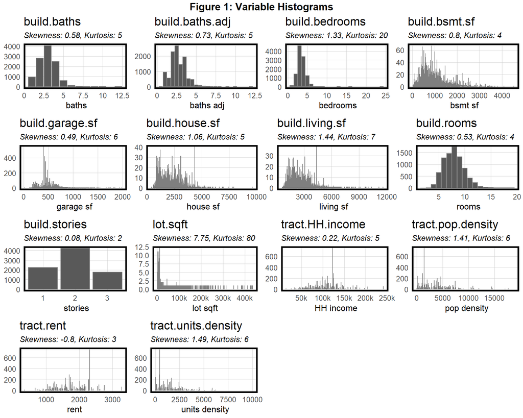

```r
fig_num = 1

str_remove_vector = function(string, removing) str_remove_all(string, paste(removing, collapse = "|")) %>% str_trim()

skewness = function(vector) sum((vector-mean(vector))^3)/((length(vector)-1)*sd(vector)^3)
## Pearson’s Coefficient of Skewness
## Skewness values and interpretation
### Symmetric:   -0.5 to 0.5
### Moderated:   -1 and -0.5; 0.5 and 1
### Highly:      less than -1; 1

kurtosis = function(vector) sum((vector-mean(vector))^4)/((length(vector)-1)*sd(vector)^4)
## Kurtosis values and interpretation
### Normal Peak (Mesokurtic): 3
### High Peak/Low Tail (Leptokurtic): >3
### Low Peak/High Tail (Platykurtic): <3

plotting = function(
  plot_df = boulder.predict.0, variables = vars.ivs.cont[1], remove_zero=TRUE,
  xlab_remove = c()
  ){
  P = list()
  #vars = names(variables)[!names(variables)%in%c('channel','label')]
  for (cont_var in variables){
    iv_col = plot_df[[cont_var]] %>% na.omit()
    skew = skewness(iv_col) %>% round(2)
    kurt = kurtosis(iv_col) %>% round()
    if(remove_zero==TRUE){
      plot_df = plot_df %>% filter(.data[[cont_var]]>0)
    }
    xlab_var = str_remove_vector(cont_var, xlab_remove) %>% gsub('.',' ', ., fixed=TRUE)
    p =
      ggplot(data=plot_df, aes(x=.data[[cont_var]])) +
        geom_histogram(color='grey50',  stat="count") +
        scale_x_continuous(
          labels=function(lab) ifelse(
            as.numeric(lab)>20000, ifelse(
              as.numeric(lab)>=500000,
              paste(round(as.numeric(lab)/1000000,1),'m',sep=''),
              paste(round(as.numeric(lab)/1000),'k',sep='')),
            lab),
          name = xlab_var
          ) +
        labs(
          title=glue('{cont_var}'),
          subtitle=glue('Skewness: {skew}, Kurtosis: {kurt}')) +
        theme(legend.position="none",
              axis.title.y = element_blank()
              ) + plotTheme()
    P = c(P, list(p))
  }
  return(list(plots=P, num=length(vars)))
}

PLOTS = plotting(boulder.predict.0,
                 vars.ivs.cont %>% sort(),
                 xlab_remove = c('build','tract'))
hist_plots = ggarrange(plotlist = PLOTS$plots)

annotate_figure(hist_plots,
                top = text_grob(
                  glue("Figure {fig_num}: Variable Histograms"),
                  face = "bold", size = 14))
```

```r
###################

cont_skewed_stats =
  boulder.predict.0 %>%
  select(vars.ivs.cont) %>%
  st_drop_geometry() %>%
  apply(.,2, skewness)

vars.ivs.cont.skew = cont_skewed_stats[abs(cont_skewed_stats)>1] %>% names(.)
var.df[var.df$var_name %in% vars.ivs.cont.skew, 'data_type'] = 'cont_skew'

vars.ivs.cont.notskew = vars.ivs.cont[!vars.ivs.cont %in% vars.ivs.cont.skew]
var.df[var.df$var_name %in% vars.ivs.cont.notskew, 'data_type'] = 'cont_notskew'
```

##Plots of Home Sales Prices & 4 Independent Variables

These scatter plots also indicate whether the relationship can be predicted using a linear model, or if we need to utilize a different method for better fit.

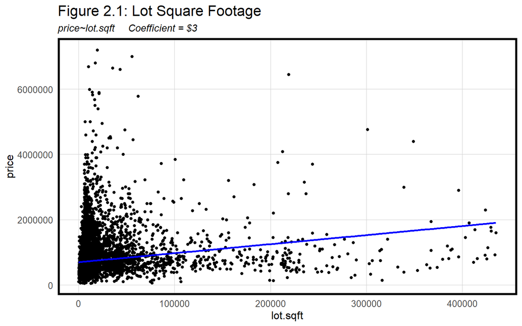

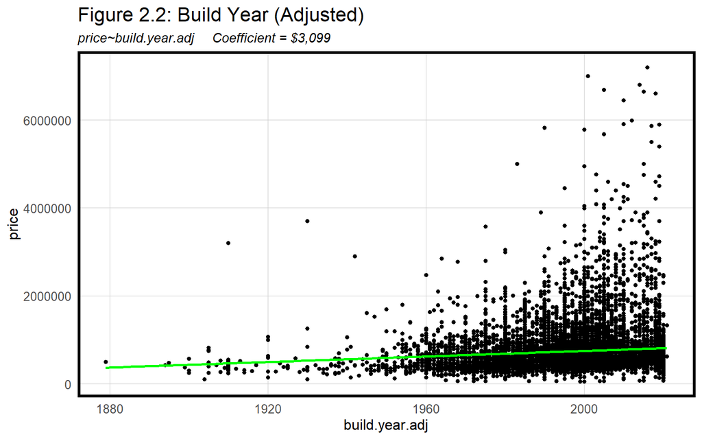

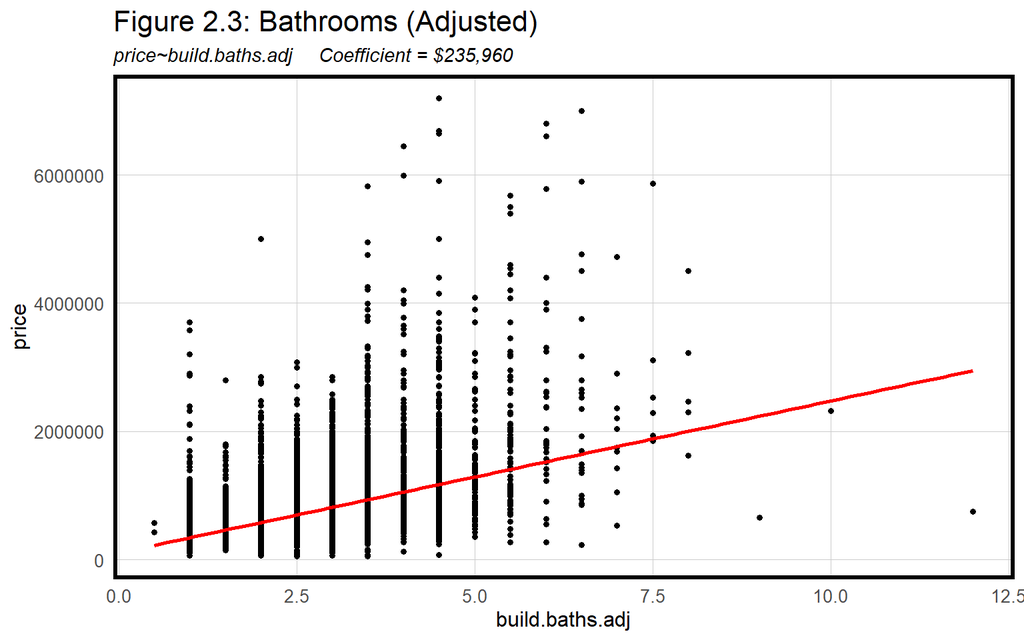

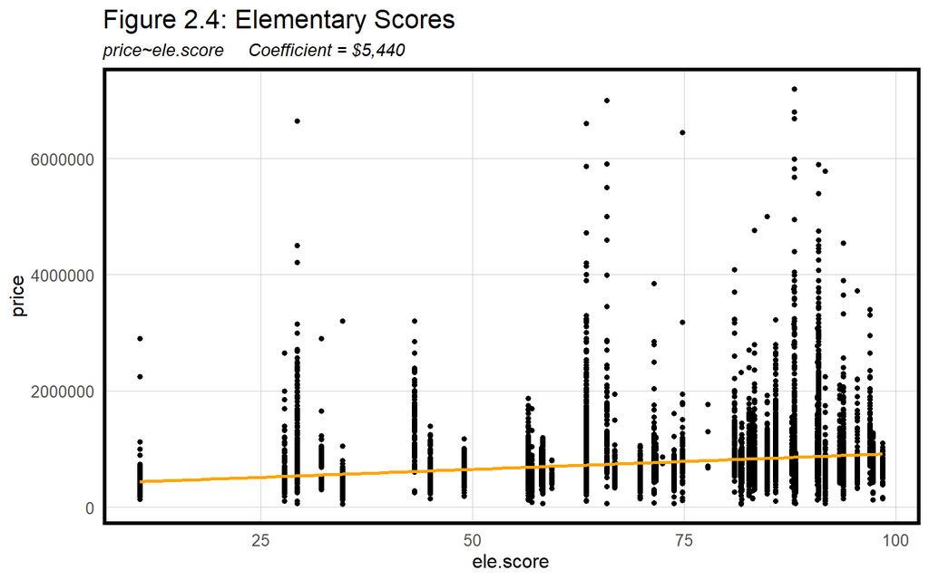

```r
fig_num = 2

dependent_variable = 'price'

plot_colors= c(
  "blue", "green", "red", "orange"
)

second_max = function(vector){
  vector_mx = max(vector)
  vector_cut =
  vector[
    vector<vector_mx]
  return(max(vector_cut))
}

ylim_num = max(boulder.predict.0$price)
ylim = second_max(boulder.predict.0$price)

## price_percentiles = ecdf(boulder.predict.0$price)
## if (price_percentiles(max(boulder.predict.0$price))==1){
##   toplim=max(
##     boulder.predict.0[
##       boulder.predict.0$price < toplim,
##       'price'] %>% st_drop_geometry(.))}

scat_vars = c('lot.sqft', 'build.year.adj','build.baths.adj', 'ele.score')
scat_labs = c('Lot Square Footage', 'Build Year (Adjusted)', 'Bathrooms (Adjusted)', 'Elementary Scores')
for (
  variable_number in seq(length(scat_vars))
){
  plot_color = plot_colors[variable_number]
  variable_name = scat_vars[variable_number]
  variable_label = scat_labs[variable_number]
  fm_equation = paste(dependent_variable, "~", variable_name, sep="")

  fm = as.formula(fm_equation)
  price_variable = lm(fm, data = boulder.predict.0)
  coefficient =
    round(
      price_variable$coefficients[variable_name][1], 2)

  scat_plot =
    ggplot(
      data = boulder.predict.0,
      aes(
        x = boulder.predict.0[[variable_name]],
        y = boulder.predict.0$price)) +
    geom_point(size=2, shape=20) +
    labs(title =
           glue("Figure {fig_num}.{variable_number}: {variable_label}"),
         subtitle = glue("{fm_equation}     Coefficient = ${coefficient %>% count_format()}")
         ) +
    geom_smooth(method = "lm", se=F,
                color = plot_color) +
    xlab(variable_name) +
    ylab("price") +
    ylim(min(boulder.predict.0$price), ylim) +
    plotTheme()
  print(scat_plot)
}
## `geom_smooth()` using formula 'y ~ x'
```

##Correlation & Independence Tests

We will primarily be using a mix of correlation and independence statistical tests in an attempt to measure relationships (1) between predictors & house price, and (2) between the predictors themselves. If there is too much of a relationship between predictor variables then ‘multicollinearity’ develops – where it becomes difficult to distinguish which variables are contributing to the model.

Ordinal or Binary variables, for example, shouldn’t use the typical Pearson correlation test. We will be following a [statistical test guide from UCLA](https://stats.idre.ucla.edu/other/mult-pkg/whatstat/).

###Continous Variables – Pearson Correlation

For the Continuous Variables, we will use a Pearson correlation as it measures the linear relationship of the raw data. Any variables with a correlation value greater than 0.8 means they are related to each other. If those related variables are both predictors, then we only need to include one of them – otherwise we are repeating the same information essentially.

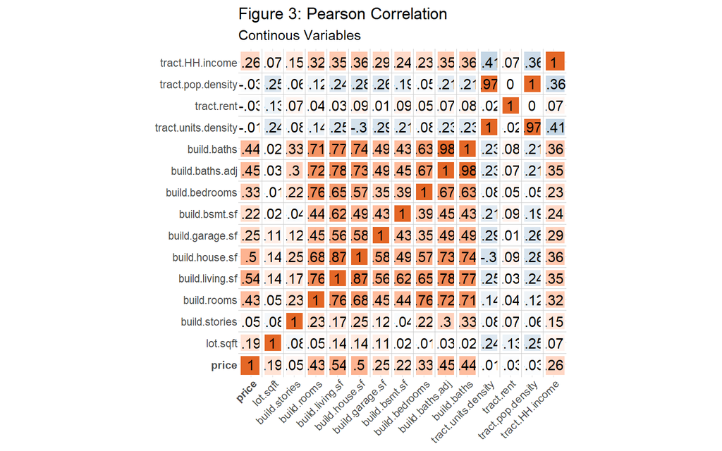

```r
fig_num = 3


ggcorr_full = function(focus_df, #focus_vars= vars,
                       focus_var = var.dv, corrmethod = 'pearson',
                       title=NULL, subtitle=NULL){
  num = ncol(boulder.cont)

  BC = 'white'
  FC = "grey80"

  BL = 2
  FL = .2
  RL = 1:num-0.5
  RL[1] = .1
  ## RL[num] = .1

  library(reshape2)

  focus_df.melt =
    cor(focus_df, method=corrmethod) %>%
    melt()


  xfaces = focus_df.melt$Var1 %>% as.character() %>% unique()
  yfaces = focus_df.melt$Var2 %>% as.character() %>% unique()

  change_focus = function(
    focus_vector, focus,
    focus_change='bold', unfocus_change='plain'){
    vector = focus_vector[]
    vector[!(vector %in% c(focus))] = unfocus_change
    vector[vector %in% c(focus)] = focus_change
    return(vector)
  }

  xfaces = change_focus(xfaces, focus_var)
  yfaces = change_focus(yfaces, focus_var)

  focus_df.melt$value =
    focus_df.melt$value %>%
    round(2)

  ggplot(focus_df.melt, aes(Var1, Var2, fill = value)) +
    geom_tile(color = "white") +
    geom_text(
      aes(Var1, Var2,
          label = gsub("0\\.", "\\.", value)),
      color = "black", size = 4) +
    scale_fill_gradient2(
      ## grey95
      low = "#6D9EC1", mid = "white", high = "#E46726",
      midpoint = 0, limit = c(-1,1), space = "Lab",
                         name="Pearson\nCorrelation") +
    theme_minimal() +
    coord_fixed() +
    theme(
          axis.text.x =
            element_text(
              face = xfaces,
              angle=45, vjust=1, hjust=1,
              margin=margin(-2,0,0,0)),
          ## axis.text.x = element_text(margin=margin(-2,0,0,0)),
          ### Order: top, right, bottom, left
          axis.text.y =
            element_text(
              face = yfaces,
              margin=margin(0,-2,0,0)),
          axis.title.x=element_blank(),
          axis.title.y=element_blank(),
          legend.position="none") +
    labs(title = title, subtitle=subtitle) +
    geom_vline(xintercept=RL, colour=BC, size=BL) +
    geom_hline(yintercept=RL, colour=BC, size=BL) +
    geom_vline(xintercept=RL, colour=FC, size=FL) +
    geom_hline(yintercept=RL, colour=FC, size=FL)}

boulder.cont =
  boulder.predict.0 %>%
  select(c(var.dv, vars.ivs.cont)) %>%
  st_drop_geometry(.)

ggcorr_full(boulder.cont,
            title = glue("Figure {fig_num}: Pearson Correlation"),
            subtitle = "Continous Variables"
            )
```

###Ordinal Variables & Continuous (Skewed Distribution) Variables – Spearman Correlation

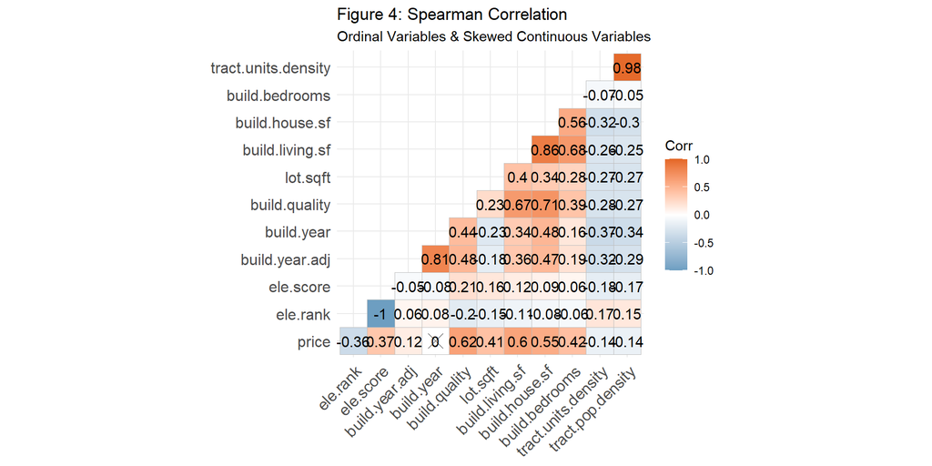

```r
fig_num = 4

boulder.cont =
  boulder.predict.0 %>%
  select(c(var.dv, vars.ivs.ordinal, vars.ivs.cont.skew)) %>%
  st_drop_geometry(.) %>%
  select_if(., is.numeric)

corrmethod = 'spearman'

ggcorrplot(
  cor(boulder.cont, method=corrmethod), #%>% round(2),
  p.mat = cor_pmat(boulder.cont, lab = TRUE, method = corrmethod),
  colors = c("#6D9EC1", "white", "#E46726"),
  type="lower",
  lab=TRUE) +
    labs(
      title = glue("Figure {fig_num}: Spearman Correlation"),
      subtitle = "Ordinal Variables & Skewed Continuous Variables")
```

to measure difference of price in the variable’s binary groups

```r
round_str = function(str_num, digits=3) str_num %>%
        as.numeric() %>%
        round(digits) %>%
        as.character() %>%
        str_replace(., "^0\\.", ".") %>%
        str_remove(., "0+$")

round_thresh = function(
  field,
  thresh = .001,
  digits = 3,
  int_check = FALSE,
  commas = FALSE
  ){

  if(is.null(field)){return('NULL')}
  if(is.na(field)){return('NA')}

  thresh_str =
    paste('<', round_str(thresh, digits=digits), sep=' ')

  field_num = field %>% as.numeric()

  field_str =
    ifelse(
      abs(field_num) < thresh,
      thresh_str,
      ifelse(
        (int_check == TRUE & abs(field_num) >= 1),
        field_num %>% round_str(digits=0),
        field_num %>% round_str(digits=digits)
        ))

  return(field_str)
}
```

```r
tab_num = 2

focus_df = boulder.predict.0 %>% st_drop_geometry() %>% select(c(var.dv,vars.ivs.binary))
ttest_df = data.frame()

for (bin_var in vars.ivs.binary){

  bin_df = focus_df %>% select(var.dv, bin_var)
  bin_FALSE = bin_df %>% filter(.data[[bin_var]]==0) %>% pull(var.dv)
  bin_TRUE = bin_df %>% filter(.data[[bin_var]]==1) %>% pull(var.dv)

  bin_test = t.test(bin_FALSE, bin_TRUE, alternative = "two.sided")

  tstat = bin_test$statistic %>% as.numeric() %>% round(2)
  doff = bin_test$parameter %>% as.numeric() %>% round()
  pval = bin_test$p.value %>% round_thresh(., thresh = .00000001,  digits = 10)
  mean_FALSE =  paste('$ ', round(mean(bin_FALSE)/1000,0), 'k', sep='')
  mean_TRUE = paste('$ ', round(mean(bin_TRUE)/1000,0), 'k', sep='')

  ttest_df = rbind(
    ttest_df,
    c(bin_var, mean_FALSE,mean_TRUE,tstat,doff,pval)
  )}
colnames(ttest_df) = c('iv', "FALSE", "TRUE", "Statistic", "Degrees of Freedom", 'P-Value')

ttest_df %>%
  kable(., caption = glue("Table {tab_num}: Paired T-Test of Binary Variables")) %>%
  kable_styling() %>%
  add_header_above(
    header=c(' '=1,'Mean Sales Price'=2,'T-Test'=3)
  ) %>%
  footnote(alphabet =
             c(
               "Two independent samples t-test",
               "significance level: 0.05"
               ))
```

| iv | Mean Sales Price FALSE | Mean Sales Price TRUE | T-Test Statistic | T-Test Degrees of Freedom | T-Test P-Value |
| --- | --- | --- | --- | --- | --- |
| build.hvac | $ 709k | $ 761k | -5 | 8116 | .0000005852 |
| build.heatsys | $ 626k | $ 745k | -2.1 | 141 | .0377225145 |
| build.garage.covered | $ 686k | $ 749k | -3.75 | 1334 | .0001816874 |
| build.bsmt.finished | $ 650k | $ 850k | -19.61 | 8849 | < .00000001 |
| build.ac | $ 708k | $ 761k | -5.1 | 8103 | .0000003404 |
| in.urban | $ 819k | $ 732k | 5.82 | 1927 | < .00000001 |
| in.city | $ 795k | $ 720k | 7.18 | 7105 | < .00000001 |
| above.AMI | $ 578k | $ 802k | -22.1 | 6300 | < .00000001 |

<sup>a</sup> Two independent samples t-test  
<sup>b</sup> significance level: 0.05

## 2.2 Maps

### 2.2.1 Set-Up Plots

```r
geom_county = function(
  data = boulder.county,
  fill = 'transparent', color='black',
  lwd=1, ...
  ){
    c_plot = geom_sf(data = data, fill = fill, color=color,
          lwd=lwd, ...)
    return(c_plot)}

geom_cities = function(
  data = boulder.cities,
  fill = 'transparent', color='grey',
  lwd=.1, linetype = "dashed",
  ...
  ){
    c_plot = geom_sf(data = data, fill = fill, color=color,
          lwd=lwd,linetype = linetype, ...)
    return(c_plot)}

plot_limits = function(
  data = boulder.cities$geometry,
  ## buffer between plot's limits and the geometry
  ## (in unit of geometry column)
  buffer = 0
){
  ## creates bounding box
  poly.bbox =
    data %>% st_union() %>%
    ## buffers the geometry so the ultimate plot has margins
    st_buffer(buffer) %>%
    st_bbox()
  return(
    ## returns the 'coord_sf' function which you can add to any plot
    coord_sf(
      xlim = c(poly.bbox['xmin'], poly.bbox['xmax']),
      ylim = c(poly.bbox['ymin'], poly.bbox['ymax']),
      crs = st_crs(data)
  ))}

st_fishnet = function(focus_sf, cell_size=500){
  focus_union = focus_sf %>% st_union()
  fishnet =
    st_make_grid(
      focus_union,
      cellsize = cell_size,
      square = TRUE) %>%
    st_intersection(focus_union) %>%
    st_sf() %>%
    mutate(id.fishnet = rownames(.))}

abs_n = function(str_num) abs(as.numeric(str_num))

format_thousand_million = function(lab)
  ifelse(abs_n(lab)>1,
    ifelse(abs_n(lab)>20000,
      ifelse(abs_n(lab)>=500000,
        paste(round(as.numeric(lab)/1000000,1),'m',sep=''),
        paste(floor(as.numeric(lab)/1000),'k',sep='')),
      lab) %>%
    str_remove(., "^0+") %>%
    sub("0+$", "", .),
  lab)

label_breaks = function(
  breaks, combiner = 'to', high_reduce=.1,
  zero_first = FALSE, above1k = FALSE
  ){
  blen = length(breaks)
  idxs = seq(blen)
  lows  = breaks[idxs[1:blen-1]]
  highs = breaks[idxs[2:blen]] - high_reduce
  highs[length(highs)] = highs[length(highs)] + high_reduce

  if(above1k==TRUE){
    highs[abs(highs)>=1000] = format_thousand_million(highs[abs(highs)>=1000])
    lows[abs(lows)>=1000] = format_thousand_million(lows[abs(lows)>=1000])
  }

  labels = paste(lows, combiner, highs)
  if(zero_first==TRUE){labels[1] = "0"}
  if(labels[1]=='0 to 0'){labels[1]='0'}
  return(labels)
}

cutting_field =
  function(var_field, var_breaks)
    cut(var_field, breaks = var_breaks, dig.lab=10, include.lowest = TRUE)
```

```r
## creating half-mile fishnets

cell_size = .5 * mile

boulder.fishnet =
  st_fishnet(boulder.county, cell_size=cell_size)

boulder.data =
  boulder.data %>%
  st_join(
    .,
    boulder.fishnet,
    suffix = c("", ".dupe_join")
  ) %>%
  select(-ends_with(".dupe_join"))

boulder.data.fishnet =
  merge(
    boulder.fishnet,
    boulder.data %>%
      mutate(
        count.homes = 1,
        count.predicted = ifelse(toPredict=="0", 1, 0),
        count.predicting = ifelse(toPredict=="1", 1, 0)
      ) %>%
      st_drop_geometry() %>%
      group_by(id.fishnet) %>%
      summarize(
        count.homes = sum(count.homes),
        count.predicted = sum(count.predicted),
        count.predicting = sum(count.predicting),
        avg.bedrooms = mean(build.bedrooms),
        avg.baths.adj = mean(build.baths.adj),
        avg.lot.sqft = mean(lot.sqft),
        avg.build.year.adj = mean(build.year.adj) %>%
          round()
      ),
    on='id.fishnet'
  ) %>%
  mutate(
    count.homes = replace_na(count.homes, 0),
    count.predicted = replace_na(count.predicted, 0),
    count.predicting = replace_na(count.predicting, 0)
    )
```

### 2.2.2 Map of Home Sales Locations

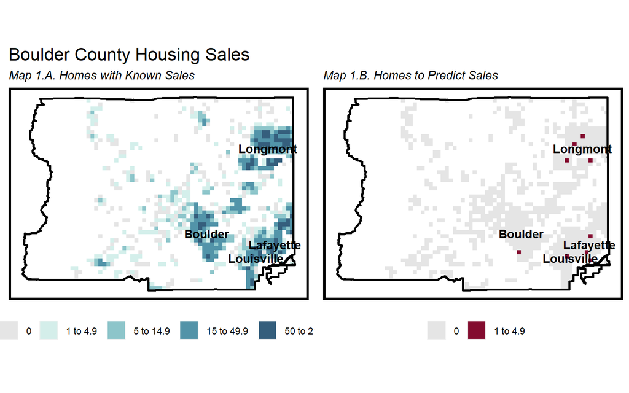

```r
map_num = 1

var_field = 'count.homes'
mx = max(boulder.data.fishnet[[var_field]])
focus_length = length(unique(boulder.data.fishnet[[var_field]]))
#var_breaks = seq(0, ceiling_10(mx))
var_breaks = c(0,1,5,15,50, mx)


boulder.data.fishnet$cut.homes =
  cutting_field(boulder.data.fishnet[[var_field]], var_breaks)
breaks_length = length(unique(boulder.data.fishnet$cut.homes))

#hcl.pals("diverging")
### "qualitative" "sequential" "diverging" "divergingx"
### https://developer.r-project.org/Blog/public/2019/04/01/hcl-based-color-palettes-in-grdevices/
pal = hcl.colors(breaks_length-1, alpha=.95, palette = "PurpOr")
pal = c('grey90',rev(pal))

house_plot =
  ggplot() +
    geom_sf(data = boulder.data.fishnet, aes(fill = cut.homes), color = NA) +
    scale_fill_manual(
      values = pal,
      labels = label_breaks(var_breaks),
      name=NULL) +
    geom_county() +
    geom_text_sf(sf_to_labels(
      boulder.cities %>% filter(incorporated=='city'),
      'name')) +
    labs(title = "All Home Sales") +
    theme(legend.position = "bottom",
        legend.spacing.x = unit(.1, 'in')) +
    mapTheme()

focus_pal = "Teal"
var_field = 'count.predicted'
boulder.data.fishnet$cut.predicted = cutting_field(boulder.data.fishnet[[var_field]], var_breaks)
pal = hcl.colors(breaks_length-1, alpha=.95, palette = focus_pal)
pal = c('grey90',rev(pal))

title = 'Boulder County Housing Sales'

predicted_plot =
  ggplot() +
    geom_sf(data = boulder.data.fishnet, aes(fill = cut.predicted), color = NA) +
    scale_fill_manual(
      values = pal,
      labels = label_breaks(var_breaks, zero_first=TRUE),
      name=NULL) +
    #geom_cities(data=boulder.cities %>% filter(incorporated=='city'), color='grey10', linetype='solid') +
    geom_county() +
    geom_text_sf(sf_to_labels(boulder.cities %>%
                                filter(incorporated=='city'), 'name')) +
    labs(
      title=title,
      subtitle = glue("Map {map_num}.A. Homes with Known Sales")) +
    theme(legend.position = "bottom",
        legend.spacing.x = unit(.1, 'in')) +
    mapTheme()

focus_pal = "YlOrRd"
var_field = 'count.predicting'
boulder.data.fishnet$cut.predicted = cutting_field(boulder.data.fishnet[[var_field]], var_breaks)
pal = hcl.colors(breaks_length-1, alpha=.95, palette = focus_pal)
pal = c('grey90',pal)

predicting_plot =
  ggplot() +
    geom_sf(data = boulder.data.fishnet, aes(fill = cut.predicted), color = NA) +
    scale_fill_manual(
      values = pal,
      labels = label_breaks(var_breaks, zero_first=TRUE),
      name=NULL) +
    #geom_cities(data=boulder.cities %>% filter(incorporated=='city'), color='grey10') +
    geom_county() +
    geom_text_sf(sf_to_labels(boulder.cities %>% filter(incorporated=='city'), 'name')) +
    labs(
      title='    ',
      subtitle = glue("Map {map_num}.B. Homes to Predict Sales"))+
    theme(legend.position = "bottom",
        legend.spacing.x = unit(.1, 'in')) +
    mapTheme()


map_grid = plot_grid(predicted_plot, predicting_plot , ncol=2)
map_grid
```

```r
## draw_label_theme = function(label, theme = NULL, element = "text", ...) {
##   if (is.null(theme)) {theme = ggplot2::theme_get()}
##   if (!element %in% names(theme)) {stop("Element must be a valid ggplot theme element name")}
##   elements = ggplot2::calc_element(element, theme)
##   cowplot::draw_label(
##     label, fontfamily = elements$family, fontface = elements$face,
##     colour = elements$color, size = elements$size, ...)}
#
## title_draw = ggdraw() +
##   draw_label_theme(
##     title, element = "plot.title",
##     x = 0.05, hjust = 0, vjust = 1)
## plot_grid(
##   title_draw, map_grid,
##   ncol = 1,
##   ## rel_heights values control vertical title margins
##   rel_heights = c(0.1, 5)
## )
```

### 2.2.3 Map of Dependent & Independent Variables

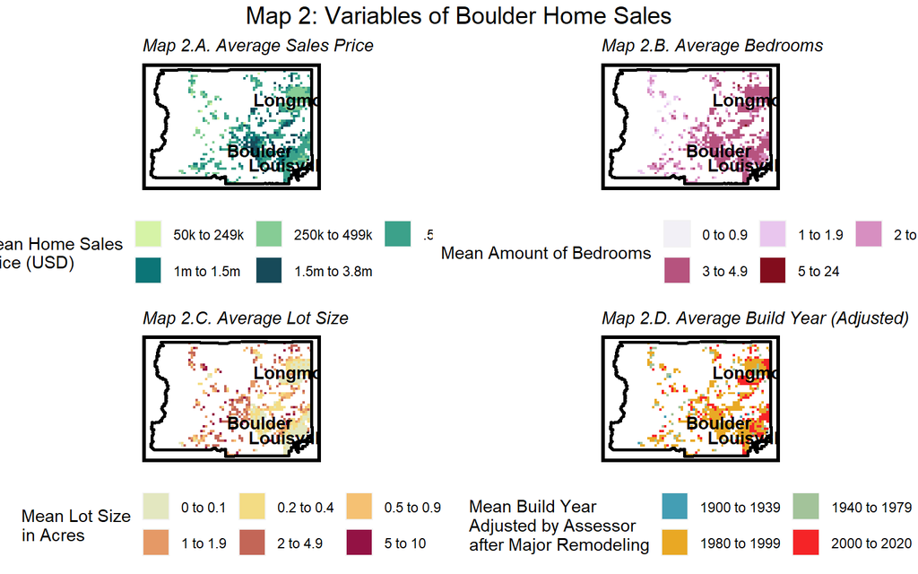

```r
map_num = 2

boulder.predict.0 =
  boulder.predict.0 %>%
  st_join(
    .,
    boulder.fishnet,
    suffix = c("", ".dupe_join")
  ) %>%
  select(-ends_with(".dupe_join"))

boulder.predict.0.fishnet =
  merge(
    boulder.fishnet,
    boulder.predict.0 %>%
      mutate(count.homes = 1) %>%
      st_drop_geometry() %>%
      group_by(id.fishnet) %>%
      summarize(
        count.homes   = sum(count.homes),
        avg.price     = mean(price),
        avg.bedrooms  = mean(build.bedrooms),
        avg.baths.adj = mean(build.baths.adj),
        avg.lot.sqft  = mean(lot.sqft),
        avg.build.year.adj = mean(build.year.adj) %>%
          round()
      ),
    on='id.fishnet'
  )%>%
  mutate(count.homes = replace_na(count.homes, 0))

var_cut_map = function(
  focus_sf = boulder.predict.0.fishnet,
  var_field = 'avg.bedrooms',
  focus_pal = "YlOrRd",
  pal_rev = FALSE,
  var_breaks_nomax = c(0,1,2,3, 5),
  var_title = 'Average Bedrooms',
  var_legend = 'Average Bedrooms',
  var_num = 'A'
  ){
  new_var_field = var_field %>%
    gsub('count','cut', .) %>% gsub('avg','cut', .)
  mx = max(focus_sf[[var_field]]) %>% ceiling()
  focus_length = length(unique(focus_sf[[var_field]]))
  #var_breaks = seq(0, ceiling_10(mx))
  var_breaks = c(var_breaks_nomax, mx)
  focus_sf[[new_var_field]] =
    cutting_field(focus_sf[[var_field]], var_breaks)
  breaks_length = length(unique(focus_sf[[new_var_field]]))
  var_pal = hcl.colors(breaks_length, #-1,
                       alpha=.95, palette = focus_pal,
                       rev = pal_rev)
  #var_pal = c('grey90',var_pal)

  fish_vars_map = function(focus_sf = focus_sf, cut_field = new_var_field,
                           cut_pal=var_pal, cut_breaks = var_breaks,
                           sub_num='A', map_title = ' ', legend_title=NULL
                           ){
    ggplot() +
      geom_sf(data = focus_sf, aes_string(fill = new_var_field), color = NA) +
      scale_fill_manual(
        values = cut_pal,
        labels = label_breaks(cut_breaks, high_reduce=ifelse(abs(cut_breaks[1])>0,1,.1),
                              above1k = ifelse(abs(cut_breaks[3])>10000,TRUE,FALSE)),
        name=legend_title) +
      #geom_cities(data=boulder.cities %>% filter(incorporated=='city'), color='grey10') +
      geom_county() +
      geom_text_sf(sf_to_labels(boulder.cities %>% filter(incorporated=='city'), 'name')) +
      labs(
        #title='',
        subtitle = glue("Map {map_num}.{sub_num}. {map_title}"))+
      theme(legend.position = "bottom",
          legend.spacing.x = unit(.1, 'in')) +
      guides(fill=guide_legend(nrow=2,byrow=TRUE)) +
      mapTheme()}

  return(fish_vars_map(focus_sf = focus_sf, cut_field = new_var_field,
                cut_pal=var_pal, cut_breaks = var_breaks,
                sub_num=var_num, map_title = var_title, legend_title=var_legend))}


Var1_map = var_cut_map(
  var_field = "avg.price",
  focus_pal = "Emrld",
  pal_rev = TRUE,
  var_breaks_nomax = c(50000,250000,500000,1000000, 1500000),
  var_title = 'Average Sales Price',
  var_legend = 'Mean Home Sales\nPrice (USD)',
  var_num = 'A'
)

Var2_map = var_cut_map(
  var_field = 'avg.bedrooms',
  focus_pal = "Red-Purple",
  pal_rev = TRUE,
  var_breaks_nomax = c(0,1,2,3, 5),
  var_title = 'Average Bedrooms',
  var_legend = 'Mean Amount of Bedrooms',
  var_num = 'B'
)

acre = 43560
boulder.predict.0.fishnet$avg.lot.acre =
  boulder.predict.0.fishnet$avg.lot.sqft/acre
boulder.predict.0.fishnet$avg.lot.acre %>% summary() #hist(breaks='fd')
##     Min.  1st Qu.   Median     Mean  3rd Qu.     Max.
## 0.000553 0.193430 0.641966 1.481778 2.073614 9.987489

Var3_map = var_cut_map(
  var_field = 'avg.lot.acre',
  focus_pal = "Heat",
  pal_rev = TRUE,
  var_breaks_nomax = c(0,.2,.5, 1, 2, 5),
  var_title = "Average Lot Size",
  var_legend = 'Mean Lot Size\nin Acres',
  var_num = 'C'
)

Var4_map = var_cut_map(
  var_field = 'avg.build.year.adj',
  focus_pal = "Zissou 1",
  pal_rev = FALSE,
  var_breaks_nomax = c(1900,1940,1980, 2000),
  var_title = "Average Build Year (Adjusted)",
  var_legend = 'Mean Build Year\nAdjusted by Assessor\nafter Major Remodeling',
  var_num = 'D'
)

title = glue('Map {map_num}: Variables of Boulder Home Sales')
grid.arrange(
  Var1_map,
  Var2_map,
  Var3_map,
  Var4_map,
  ncol=2,
  top = textGrob(title,gp=gpar(fontsize=15))
)
```

### 2.2.4 Map of Voting Precincts/Neighborhoods

In a later spatial model test, we will be aggregating housing sales by neighborhoods. This map visualizes the voting precincts we will use like neighborhoods.

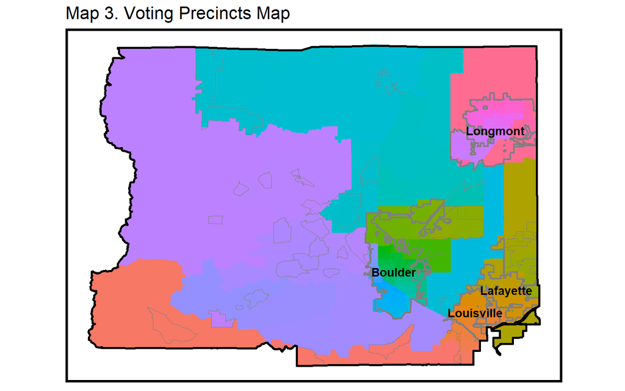

```r
map_num = 3
ggplot() +
  ## geom_sf(
  ##   data = boulder.cities,
  ##   aes(fill=incorporated),
  ##   color='transparent') +
  geom_sf(
    data = boulder.nhoods,
    aes(fill=nhood_id),
    color='transparent',
    lwd=0.1) +
  scale_fill_hue() +
  #geom_cities(lwd=0.1, color='grey25') +
  geom_cities(
    boulder.cities,
    lwd=ifelse(boulder.cities$incorporated=='city', .75,.1), color='grey50', linetype='solid'
    ) +
  geom_county() +
  geom_text_sf(sf_to_labels(
    boulder.cities %>% filter(incorporated=='city'),
    'name')) +
  theme(legend.position = "none") +
  labs(title = glue("Map {map_num}. Voting Precincts Map")) +
  #plot_limits() +
  mapTheme()
```

## 2.3 Choose Final Variables

```r
var.ivs = c(

  ## Continuous
  "lot.sqft",
  "build.living.sf",
  "build.garage.sf",
  "build.bedrooms",
  "build.baths.adj",
  "tract.HH.income",

  ## ordinal
  "ele.score",
  "build.year.adj",
  "build.quality",

  ## binary
  "build.hvac",
  "build.bsmt.finished",
  "in.city",
  "above.AMI"
)
```

# 3 3. Linear Model Results

## 3.1 Methods

## 3.2 Partition Training & Test Sets

Before developing the model, this study splits the dataset of known home prices [boulder.predict.0] before training a linear model so we can test that model on unbiased data. Specifically, 75% of the known home prices are randomly split into the training dataset [boulder.train] – while 25% goes into an unbiased test set [boulder.test].

```r
select_v = function(sf, variable_names=c('price', var.ivs)){
  return(sf %>% st_drop_geometry(.) %>%
             select(variable_names))}

select_iv = function(sf, variable_names=var.ivs){
  return(sf %>% st_drop_geometry(.) %>%
             select(variable_names))}

inTrain = createDataPartition(
              y = boulder.predict.0 %>% pull(price),
              p = .75, list = FALSE)

boulder.train =
  boulder.predict.0[inTrain,] %>%
  select(c(vars.admin,var.dv,var.ivs))
## Note: Using an external vector in selections is ambiguous.
## i Use `all_of(vars.admin)` instead of `vars.admin` to silence this message.
## i See <https://tidyselect.r-lib.org/reference/faq-external-vector.html>.
## This message is displayed once per session.
## Note: Using an external vector in selections is ambiguous.
## i Use `all_of(var.ivs)` instead of `var.ivs` to silence this message.
## i See <https://tidyselect.r-lib.org/reference/faq-external-vector.html>.
## This message is displayed once per session.

boulder.test =
  boulder.predict.0[-inTrain,] %>%
  select(c(vars.admin,var.dv,var.ivs))
```

## 3.3 Train Model

With a training set, the study can now build its initial training linear model [lm.train] based on the predictor variables constructed in Section 1.

### 3.3.1 Fitting a Linear Model

```r
#var.ivs = var.ivs %>% list()
var.dv = var.dv

var.ivs.str =
  do.call(paste, c(var.ivs %>% list(), collapse = "+"))

fm_equation = as.formula(paste(
  var.dv, var.ivs.str, sep="~"))

print(fm_equation)
## price ~ lot.sqft + build.living.sf + build.garage.sf + build.bedrooms +
##     build.baths.adj + tract.HH.income + ele.score + build.year.adj +
##     build.quality + build.hvac + build.bsmt.finished + in.city +
##     above.AMI


lm.train =
  lm(
    fm_equation,
    data = boulder.train %>% select_v(.)
    )
```

### 3.3.2 Training Summary Table

The results of our model on the training set are presented below.

```r
tab_num = 3
# stargazer(
#   lm.train,
#   type="text", digits=1,
#   title="Table 2: Boulder Training Data Regression Output")

format_nums = function(num_input, digits = 2) ifelse(abs(num_input)>999,
                      count_format(num_input),
                      round_thresh(num_input, digits = digits,int_check = TRUE))
lm.train %>% summary()
##
## Call:
## lm(formula = fm_equation, data = boulder.train %>% select_v(.))
##
## Residuals:
##      Min       1Q   Median       3Q      Max
## -1650246  -194916   -41125   106120  6932696
##
## Coefficients:
##                         Estimate   Std. Error t value
## (Intercept)         7201641.7187  650275.2815  11.075
## lot.sqft                  1.5674       0.1402  11.181
## build.living.sf         134.2563       8.1450  16.483
## build.garage.sf        -258.3055      23.8999 -10.808
## build.bedrooms        -3071.4168    6095.9451  -0.504
## build.baths.adj       36746.2634    8101.6645   4.536
## tract.HH.income           1.1489       0.1918   5.992
## ele.score              3320.7818     221.8447  14.969
## build.year.adj        -4160.6060     329.3326 -12.633
## build.quality         31698.6371     906.1098  34.983
## build.hvac           -77531.3175   11056.8319  -7.012
## build.bsmt.finished    9486.7675   10164.5032   0.933
## in.city              186975.7597   11069.9492  16.890
## above.AMI            -81677.3805   15125.5916  -5.400
##                                 Pr(>|t|)
## (Intercept)         < 0.0000000000000002 ***
## lot.sqft            < 0.0000000000000002 ***
## build.living.sf     < 0.0000000000000002 ***
## build.garage.sf     < 0.0000000000000002 ***
## build.bedrooms                     0.614
## build.baths.adj         0.00000582337732 ***
## tract.HH.income         0.00000000216555 ***
## ele.score           < 0.0000000000000002 ***
## build.year.adj      < 0.0000000000000002 ***
## build.quality       < 0.0000000000000002 ***
## build.hvac              0.00000000000253 ***
## build.bsmt.finished                0.351
## in.city             < 0.0000000000000002 ***
## above.AMI               0.00000006850314 ***
## ---
## Signif. codes:  0 '***' 0.001 '**' 0.01 '*' 0.05 '.' 0.1 ' ' 1
##
## Residual standard error: 397000 on 8306 degrees of freedom
## Multiple R-squared:  0.4454, Adjusted R-squared:  0.4446
## F-statistic: 513.2 on 13 and 8306 DF,  p-value: < 0.00000000000000022
lm.train.summ =
  lm.train %>%
  tidy() %>%
  transmute(
    Variable =
      ifelse(term %in% vars.ivs.binary,
             paste(term, '(X = 1)'),
             term
        ),
    Estimate = format_nums(estimate, digits = 3) %>%
      paste('$', .),
    std.error = format_nums(std.error) %>%
      paste('$', .),
    t.value = format_nums(statistic),
    p.value = p.value %>% round_thresh()
  )

lm.train.summ %>%
  kable(caption =
          glue('Table {tab_num}: Training Model Summary'),
        align = 'lrrrr') %>%
  kable_styling()
```

(#tab:table_train_summ)Table 3: Training Model Summary

| Variable | Estimate | std.error | t.value | p.value |
| --- | --- | --- | --- | --- |
| (Intercept) | $ 7,201,642 | $ 650,275 | 11 | < .001 |
| lot.sqft | $ 2 | $ .14 | 11 | < .001 |
| build.living.sf | $ 134 | $ 8 | 16 | < .001 |
| build.garage.sf | $ -258 | $ 24 | -11 | < .001 |
| build.bedrooms | $ -3,071 | $ 6,096 | -0.5 | .614 |
| build.baths.adj | $ 36,746 | $ 8,102 | 5 | < .001 |
| tract.HH.income | $ 1 | $ .19 | 6 | < .001 |
| ele.score | $ 3,321 | $ 222 | 15 | < .001 |
| build.year.adj | $ -4,161 | $ 329 | -13 | < .001 |
| build.quality | $ 31,699 | $ 906 | 35 | < .001 |
| build.hvac (X = 1) | $ -77,531 | $ 11,057 | -7 | < .001 |
| build.bsmt.finished (X = 1) | $ 9,487 | $ 10,165 | .93 | .351 |
| in.city (X = 1) | $ 186,976 | $ 11,070 | 17 | < .001 |
| above.AMI (X = 1) | $ -81,677 | $ 15,126 | -5 | < .001 |

```r
tab_num = 4

lm.train %>% glance() %>%
  transmute(
    `RSE` = format_nums(sigma) %>%
      paste('$', .),
    `df ` = format_nums(df.residual),
    `Multiple` = format_nums(r.squared, digits=4),
    `Adjusted` = format_nums(adj.r.squared, digits=4),
    `stat` = format_nums(statistic, digits=1),,
    `df` = format_nums(df),
    p.value = p.value %>% round_thresh()
  ) %>%
  kable(caption =
          glue('Table {tab_num}: Training Model Fit & Significance Terms'),
        align = 'lrrrr') %>%
  kable_styling() %>%
  add_header_above(
    header = c(
      'Residual Standard Error'=2,
      'R-squared' = 2,
      'F-statistic' = 2,
      ' ' = 1
    ))
```

(#tab:table_train_err)Table 4: Training Model Fit & Significance Terms

| Residual Standard Error RSE | Residual Standard Error df | R-squared Multiple | R-squared Adjusted | F-statistic stat | F-statistic df | p.value |
| --- | --- | --- | --- | --- | --- | --- |
| $ 397,003 | 8,306 | .4454 | .4446 | 513 | 13 | < .001 |

### 3.3.3 Test Errors Table

```r
tab_num = 5

boulder.test =
  boulder.test %>%
  mutate(
    regression      = "Boulder Test Regression",
    price.predict   = predict(lm.train, .),

    # residuals
    price.error     = price - price.predict,
    price.rmse      = sqrt(mean((price.error)^2)),
    price.abserror  = abs(price.predict - price),
    price.ape       = price.abserror / price
    )

# Mean Error
test.ME =
  mean(boulder.test$price.error, na.rm = T)

# Mean Absolute Error (MAE)
test.MAE =
  mean(boulder.test$price.abserror, na.rm = T)

# Mean Absolute Percentage Error (MAPE)
test.MAPE =
  mean(boulder.test$price.ape, na.rm = T)

# Mean Squared Error (MSE)
test.MSE =
  mean((boulder.test$price.error)^2)

# Root Mean Squared Error (RMSE)
test.RMSE =
  boulder.test$price.rmse[1]


# Mean Prediction
test.mean.prediction =
  mean(boulder.test$price.predict, na.rm = T)

data.frame(
  N = nrow(boulder.test) %>% format_nums(),
  `MAE` = test.MAE %>% format_nums()%>%
      paste('$', .),
  `MAPE` =
    (test.MAPE * 100) %>% round_thresh(
      ., digits = 3, int_check = FALSE) %>%
      paste(., '%'),
  `RMSE` = test.RMSE %>% format_nums()%>%
      paste('$', .)
  )%>%
  kable(caption =
          glue('Table {tab_num}: Training Model Fit & Significance Terms'),
        align = 'rrrr') %>%
  kable_styling()
```

| N | MAE | MAPE | RMSE |
| --- | --- | --- | --- |
| 2,770 | $ 231,471 | 32.697 % | $ 381,015 |

### 3.3.4 Plot Sales Price and Error

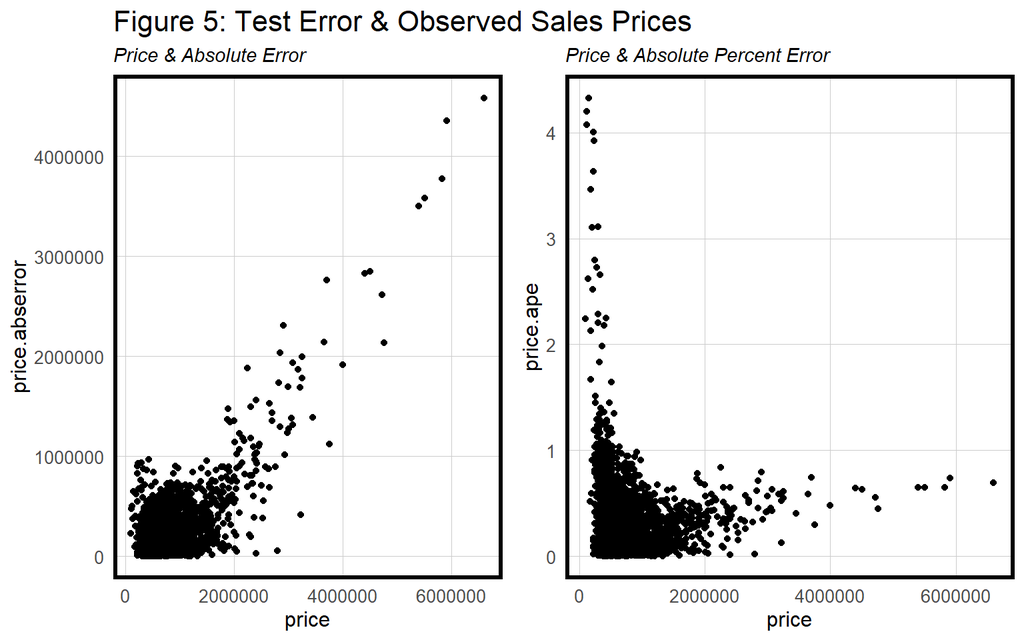

```r
fig_num = 5
title = glue('Figure {fig_num}: Test Error & Observed Sales Prices')

grid.arrange(ncol=2,
  ggplot(data = boulder.test) +
    geom_point(aes(x = price, y = price.abserror)) +
    labs(title=title,
      subtitle = "Price & Absolute Error") +
    plotTheme(),

  ggplot(data = boulder.test) +
    geom_point(aes(x = price, y = price.ape)) +
    labs(title='', subtitle = "Price & Absolute Percent Error") +
    plotTheme()
)
```

```r
# boulder.predict.0.cv %>% filter(price.ape>5) %>%
#   arrange(price.ape) #%>% select_v()
```

## 3.4 K-Fold Cross-Validation Model

### 3.4.1 Create CV Model with 100 Folds

*Provide the results of your cross-validation tests – 100 folds.* *This includes mean and standard deviation MAE.*

Next, we have to account for generalizability, in order for our model to be effective at predicting unknown, future data. We run a k-fold test on 100 of segments of our data equally split up, and then find the mean average error.

```r
# k-fold cross-validation
set.seed(825)


train.control =
  trainControl(
    method = "cv",
    number = 100,
    savePredictions = TRUE)

# was train.cv
train.cv =
  train(price ~ .,
    data = boulder.train %>% select_v(.),
    method = "lm",
    trControl = train.control, na.action = na.pass)
```

### 3.4.2 Table of Resampled Cross-Validation

```r
tab_num = 6

boulder.predict.0.cv =
  boulder.predict.0 %>%
  select_v() %>%
  mutate(
    regression     = "Final CV Regression",
    price.predict  = predict(train.cv, .),

    # Residual
    price.error     = price - price.predict,
    price.abserror = abs(price.predict - price),
    price.ape      = (price.abserror / price),

    price.SE = (price.error)^2,
    price.rmse  = sqrt(mean(price.SE))
  )

train.cv.rs = train.cv$resample
train.cv.final = train.cv$finalModel

train.cv.100_final =
  rbind(
    data.frame(
      Model = c('Training Model'),
      Dataset = c("Testing (25%)"),
      MAE.mean = test.MAE %>%
        format_nums() %>% paste('$', .),
      MAE.sd   = '',
      RMSE.mean = test.RMSE %>%
        format_nums() %>% paste('$', .),
      RMSE.sd   = '',
      R2.mean = glance(lm.train)$r.squared %>%
        format_nums(., digits=4),
      R2.sd   = ''
    ),
    data.frame(
      Model = "100-Folds CV",
      Dataset = "Training (75%)",
      MAE.mean = train.cv.rs$MAE %>% mean() %>%
        format_nums() %>% paste('$', .),
      MAE.sd   = train.cv.rs$MAE %>% sd() %>%
        format_nums() %>% paste('$', .),
      RMSE.mean = train.cv.rs$RMSE %>% mean() %>%
        format_nums() %>% paste('$', .),
      RMSE.sd   = train.cv.rs$RMSE %>% sd() %>%
        format_nums() %>% paste('$', .),
      R2.mean = train.cv.rs$Rsquared %>% mean() %>%
        format_nums(., digits=4),
      R2.sd   = train.cv.rs$Rsquared %>% sd() %>%
        format_nums(., digits=4)
    ),
    data.frame(
      Model = c('Final CV'),
      Dataset = c("Observed House Sales"),
      MAE.mean = boulder.predict.0.cv$price.abserror %>% mean() %>%
        format_nums() %>% paste('$', .),
      MAE.sd   = '',
      RMSE.mean = boulder.predict.0.cv$price.rmse[1] %>%
        format_nums() %>% paste('$', .),
      RMSE.sd   = '',
      R2.mean =  glance(train.cv.final)$r.squared %>%
        format_nums(., digits=4),
      R2.sd   = ''
    )
  )


train.cv.100_final %>%
  kable(
    caption = glue("Table {tab_num}: Regression Results of One Test Set"),
    col.names = c('Model', 'Dataset', 'Mean', 'SD', 'Mean', 'SD','Mean', 'SD')) %>%
  kable_styling() %>%
  add_header_above(
    header=c(' ' = 2, 'MAE'=2, 'RMSE'=2, 'R-Squared'=2)
  ) %>%
  footnote(alphabet =
             c(
               "Final Model's Mean's columns are just the single statistic observation"
               ))
```

(#tab:table_train_cv)Table 6: Regression Results of One Test Set

| Model | Dataset | MAE Mean | MAE SD | RMSE Mean | RMSE SD | R-Squared Mean | R-Squared SD |
| --- | --- | --- | --- | --- | --- | --- | --- |
| Training Model | Testing (25%) | $ 231,471 |  | $ 381,015 |  | .4454 |  |
| 100-Folds CV | Training (75%) | $ 234,547 | $ 30,314 | $ 380,937 | $ 114,470 | .4759 | .1006 |
| Final CV | Observed House Sales | $ 233,409 |  | $ 392,817 |  | .4454 |  |

<sup>a</sup> Final Model’s Mean’s columns are just the single statistic observation

### 3.4.3 Histogram of MAE

*cross-validation MAE as a histogram.*

The histogram below shows the distribution of mean average error across the 100 folds of the K-test.

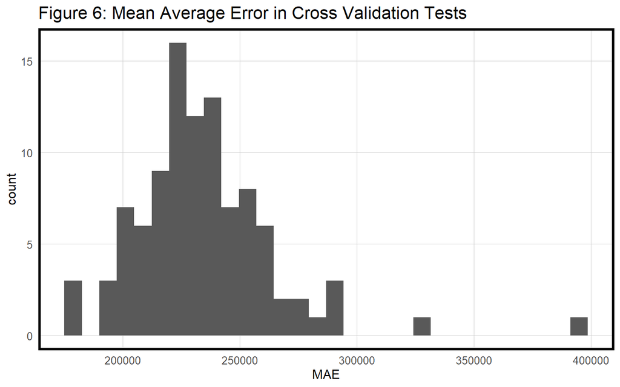

```r
fig_num = 6

ggplot(train.cv$resample, aes(x=MAE)) +
  geom_histogram() +
  labs(title = glue("Figure {fig_num}: Mean Average Error in Cross Validation Tests")) +
  plotTheme()
## `stat_bin()` using `bins = 30`. Pick better value with `binwidth`.
```

## 3.5 Model Results

*Is your model generalized to new data?*

### 3.5.1 Predict All Home Prices

*Run Final Model on all Homes in the data set*

```r
boulder.predict =
  rbind(
    boulder.predict.0[, colnames(boulder.predict.1)],
    boulder.predict.1
  ) %>%
  mutate(
    regression      = "Final Regression",
    price.predict   = predict(train.cv, .),

    # Residual
    price.error     = price - price.predict,
    price.abserror = abs(price.predict - price),
    price.ape      = (price.abserror / price),

    price.rmse  = sqrt(mean((price.error)^2, na.rm=TRUE))
  ) %>%
  filter(
    price<price_max_threshold
    )
```

### 3.5.2 Plot Predicted Prices over Observed Prices

*Plot predicted prices as a function of observed prices*

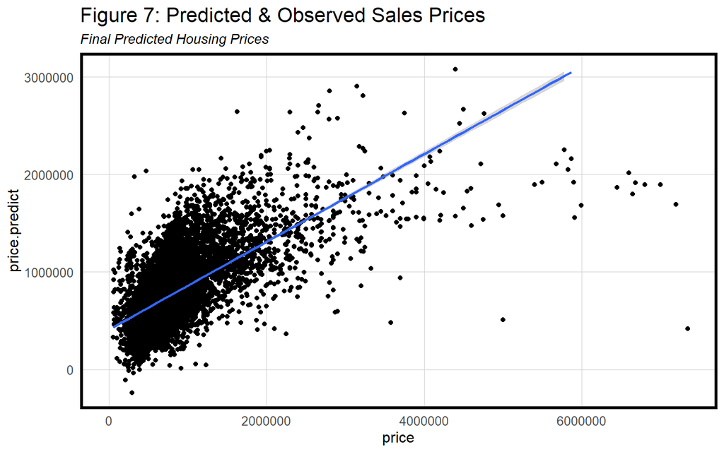

```r
fig_num = 7
title = glue('Figure {fig_num}: Predicted & Observed Sales Prices')

line_min = min(max(boulder.predict$price), max(boulder.predict$price.predict))

ggplot() +
    # geom_line(data=data.frame(
    #     x=c(0,line_min),
    #     y=c(0,line_min)),
    #     aes(x=x,y =y),
    #             linetype = "dashed", size=.75, color='grey50') +
    geom_point(data = boulder.predict, aes(x = price, y = price.predict)) +
    geom_smooth(data = boulder.predict, aes(x = price, y = price.predict), method = lm) +
    labs(title=title,
      subtitle = "Final Predicted Housing Prices") +
    xlim(min(boulder.predict$price,0), max(boulder.predict$price)) +
    ylim(min(boulder.predict$price.predict,0), max(boulder.predict$price.predict)) +
    plotTheme()
## `geom_smooth()` using formula 'y ~ x'
```

### 3.5.3 Map Predicted & Observed Prices

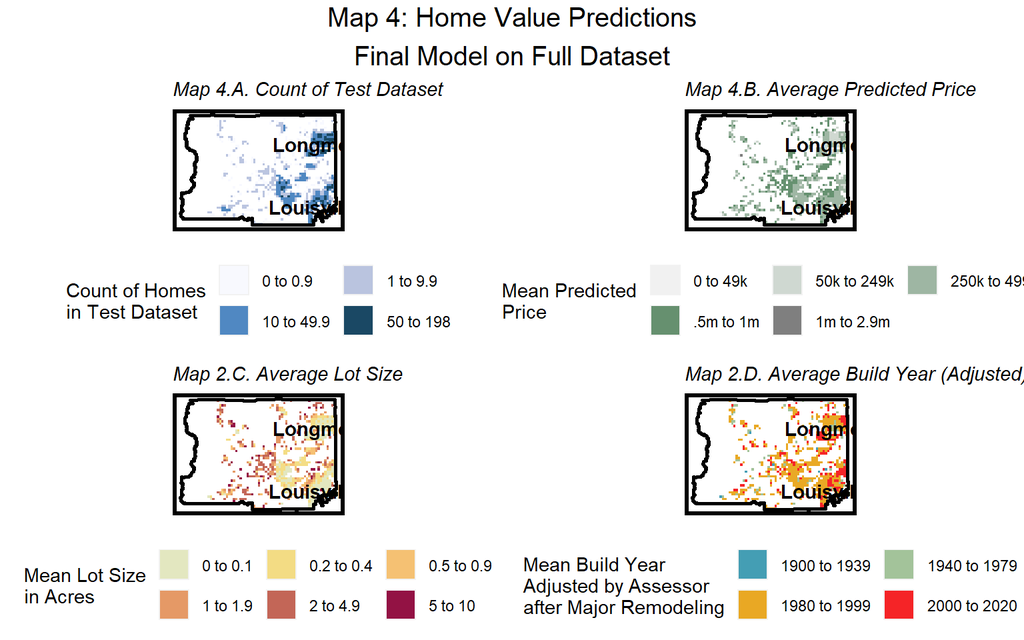

```r
map_num = 4

boulder.predict =
  boulder.predict %>%
  st_join(
    .,
    boulder.fishnet,
    suffix = c("", ".dupe_join")
  ) %>%
  select(-ends_with(".dupe_join"))

boulder.predict.fishnet =
  merge(
    boulder.fishnet,
    boulder.predict %>%
      mutate(count.homes = 1) %>%
      st_drop_geometry() %>%
      group_by(id.fishnet) %>%
      summarize(
        count.homes = sum(count.homes, na.rm=TRUE),
        MAE = mean(price.abserror, na.rm=TRUE),
        ME  = mean(price.error, na.rm=TRUE),
        MPE = mean(price.abserror / price, na.rm=TRUE),
        avg.price.predict = mean(price.predict, na.rm=TRUE),
        avg.price  = mean(price, na.rm=TRUE)
      ),
    on='id.fishnet'
  )%>%
  mutate(
    count.homes = replace_na(count.homes, 0),
    avg.price.predict = replace_na(avg.price.predict, 0))

Var1_map = var_cut_map(
  focus_sf = boulder.predict.fishnet,
  var_field = "count.homes",
  focus_pal = "PuBu",
  pal_rev = TRUE,
  var_breaks_nomax = c(0,1,10,50),
  var_title = 'Count of Test Dataset',
  var_legend = 'Count of Homes\nin Test Dataset',
  var_num = 'A'
)

Var2_map = var_cut_map(
  focus_sf = boulder.predict.fishnet,
  var_field = 'avg.price.predict',
  focus_pal = "Greens 2",
  pal_rev = TRUE,
  var_breaks_nomax = c(0, 50000,250000,500000,1000000),
  var_title = 'Average Predicted Price',
  var_legend = 'Mean Predicted\nPrice',
  var_num = 'B'
)

title = glue('Map {map_num}: Home Value Predictions\nFinal Model on Full Dataset')
grid.arrange(
  Var1_map,
  Var2_map,
  Var3_map,
  Var4_map,
  ncol=2,
  top = textGrob(title,gp=gpar(fontsize=15))
)
```

# 4 4. Spatial Model Results

Section 3 was able to create a method of predicting housing prices for homes in Boulder County. Even though the independent variables used to predict housing prices included spatial features, the results were not spatially visualized or analyzed.

> There are three things that matter in property: **location, location, location**

> — *Lord Harold Samuel[1](https://journals.sagepub.com/doi/pdf/10.1177/0363546513511052)*

In this section, the study will examine if the housing price predictions are spatially correlated.

## 4.1 Find Spatial Lag of Predictions

*Using the Price Prediction and Location of All Homes in the dataset*

### 4.1.1 Set-Up

*Find Neighbors of All Homes*

```r
boulder.test.weights =
  boulder.test %>%
  # all coordinates
  st_coordinates(.) %>%
  # 5-nearest neighbor list
  knearneigh(., 5) %>%
  knn2nb(.) %>%
  # spatial weights
  nb2listw(., style="W")

boulder.test =
  boulder.test %>%
  mutate(
    price.lag =
      lag.listw(boulder.test.weights, price),
    price.error.lag =
      lag.listw(boulder.test.weights, price.error)
  )
```

### 4.1.2 Plot Spatial Lag and Errors over Price

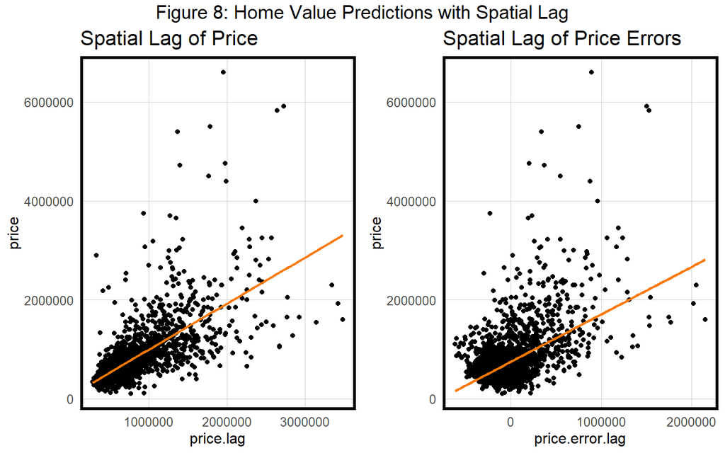

```r
fig_num = 8

title = glue('Figure {fig_num}: Home Value Predictions with Spatial Lag')
grid.arrange(ncol=2,
  ggplot(boulder.test, aes(price.lag, price)) +
    geom_point() +
    stat_smooth(aes(price.lag, price),
               method = "lm", se = FALSE, size = 1, colour="#FA7800")+
    labs(title = "Spatial Lag of Price") +
    plotTheme(),

  ggplot(boulder.test, aes(price.error.lag, price)) +
    geom_point() +
    stat_smooth(aes(price.error.lag, price),
               method = "lm", se = FALSE, size = 1, colour="#FA7800")+
    labs(title = "Spatial Lag of Price Errors") +
    plotTheme(),
  top = textGrob(title,gp=gpar(fontsize=15))
)
## `geom_smooth()` using formula 'y ~ x'
## `geom_smooth()` using formula 'y ~ x'
```

### 4.1.3 Moran’s I of Prediction Errors

*Using the Residuals of the Test Set Prediction*

[figure not shown]

```r
boulder.test.MoransI =
  moran.mc(
    boulder.test$price.error,
    boulder.test.weights,
    nsim = 999
    )

boulder.test.MoransI %>% str()
## List of 7
##  $ statistic  : Named num 0.428
##   ..- attr(*, "names")= chr "statistic"
##  $ parameter  : Named num 1000
##   ..- attr(*, "names")= chr "observed rank"
##  $ p.value    : num 0.001
##  $ alternative: chr "greater"
##  $ method     : chr "Monte-Carlo simulation of Moran I"
##  $ data.name  : chr "boulder.test$price.error \nweights: boulder.test.weights  \nnumber of simulations + 1: 1000 \n"
##  $ res        : num [1:1000] -0.01293628 0.00000839 0.01091729 -0.00941396 0.008751 ...
##  - attr(*, "class")= chr [1:2] "htest" "mc.sim"

ggplot(
    boulder.test.MoransI$res[c(1:999)] %>% as.data.frame(),
    aes(boulder.test.MoransI$res[c(1:999)])
  ) +
  geom_histogram(binwidth = 0.01) +
  geom_vline(
    aes(xintercept = boulder.test.MoransI$statistic),
    colour = "#FA7800",size=1) +
  #scale_x_continuous(limits = c(-1, 1)) +
  labs(
    title="Figure XX: Observed and Permuted Moran's I",
    subtitle= "Observed Moran's I in orange",
    x="Moran's I",
    y="Count") +
  plotTheme()
```

### 4.1.4 Map of Test Predictions

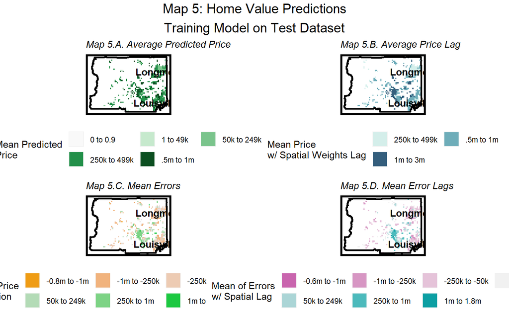

```r
map_num = 5

boulder.test =
  boulder.test %>%
  st_join(
    .,
    boulder.fishnet,
    suffix = c("", ".dupe_join")
  ) %>%
  select(-ends_with(".dupe_join"))

boulder.test.fishnet =
  merge(
    boulder.fishnet,
    boulder.test %>%
      mutate(count.homes = 1) %>%
      st_drop_geometry() %>%
      group_by(id.fishnet) %>%
      summarize(
        count.homes = sum(count.homes, na.rm=TRUE),
        MAE = mean(price.abserror, na.rm=TRUE),
        ME  = mean(price.error, na.rm=TRUE),
        MPE = mean(price.abserror / price, na.rm=TRUE),
        avg.price.predict = mean(price.predict, na.rm=TRUE) %>%
          as.numeric(),
        avg.price  = mean(price, na.rm=TRUE) %>%
          as.numeric(),
        avg.price.lag       = mean(price.lag, na.rm=TRUE) %>%
          as.numeric(),
        avg.price.error.lag = mean(price.error.lag, na.rm=TRUE) %>%
          as.numeric()
      ),
    on='id.fishnet'
  )%>%
  mutate(
    count.homes = replace_na(count.homes, 0),
    avg.price.lag = replace_na(avg.price.lag, 0),
    avg.price.error.lag = replace_na(avg.price.error.lag, 0)
    )

# Var1_map = var_cut_map(
#   focus_sf = boulder.test.fishnet,
#   var_field = "count.homes",
#   focus_pal = "PuBu",
#   pal_rev = TRUE,
#   var_breaks_nomax = c(0,1,5,15),
#   var_title = 'Count of Test Dataset',
#   var_legend = 'Count of Homes\nin Test Dataset',
#   var_num = 'A'
# )

Var1_map = var_cut_map(
  focus_sf = boulder.test.fishnet,
  var_field = 'avg.price.predict',
  focus_pal = "Greens 3",
  pal_rev = TRUE,
  var_breaks_nomax = c(0, 1, 50000,250000,500000,1000000),
  var_title = 'Average Predicted Price',
  var_legend = 'Mean Predicted\nPrice',
  var_num = 'A'
)

Var2_map = var_cut_map(
  focus_sf = boulder.test.fishnet,
  var_field = 'avg.price.lag',
  focus_pal = "Teal",
  pal_rev = TRUE,
  var_breaks_nomax = c(250000,500000,1000000),
  var_title = 'Average Price Lag',
  var_legend = 'Mean Price\nw/ Spatial Weights Lag',
  var_num = 'B'
)

min_me = min(boulder.test.fishnet[['ME']])
Var3_map = var_cut_map(
  focus_sf = boulder.test.fishnet,
  var_field = 'ME',
  focus_pal = "Green-Orange",
  pal_rev = TRUE,
  var_breaks_nomax = c(min_me, -1000000, -249999, -49999, 50000, 250000,1000000),
  var_title = "Mean Errors",
  var_legend = 'Mean of Price\n - Prediction',
  var_num = 'C'
)

min_me = min(boulder.test.fishnet[['avg.price.error.lag']])
Var4_map = var_cut_map(
  focus_sf = boulder.test.fishnet,
  var_field = 'avg.price.error.lag',
  focus_pal = "Tropic",
  pal_rev = TRUE,
  var_breaks_nomax = c(min_me, -1000000, -249999, -49999, 50000, 250000,1000000),
  var_title = "Mean Error Lags",
  var_legend = 'Mean of Errors\nw/ Spatial Lag',
  var_num = 'D'
)

title = glue('Map {map_num}: Home Value Predictions\nTraining Model on Test Dataset')
grid.arrange(
  Var1_map,
  Var2_map,
  Var3_map,
  Var4_map,
  ncol=2,
  top = textGrob(title,gp=gpar(fontsize=15))
)
```

## 4.2 Predictions with Neighborhoods

### 4.2.1 Set Up Neighborhood Effects

*Using the Training Dataset* *Create Neighborhood Linear Model & Combine Datasets*

```r
tab_num = 7

#neighborhood regression
lm.test.nhood =
  lm(
    price ~ .,
    data = boulder.test %>%
      select(c('nhood_id', 'price', var.ivs)) %>%
      st_drop_geometry()
    )

boulder.test.nhood =
  boulder.test %>%
  mutate(
    regression      = "Neighborhood Effects",
    price.predict   =
      predict(
        lm.test.nhood,
        .),
    # residuals
    price.error     = price - price.predict,
    price.rmse      = sqrt(mean((price.error)^2)),
    price.abserror  = abs(price.predict - price),
    price.ape       = price.abserror / price,

    price.error.lag = lag.listw(boulder.test.weights, price.error)
    )

boulder.test.linear_nhood =
  rbind(
    boulder.test, #%>%
     # regression = "Boulder Test Regression"
      #select(., starts_with("price"), regression, nhood_id),
    boulder.test.nhood #%>%
      # regression = "Neighborhood Effects"
      #select(., starts_with("price"), regression, nhood_id)
  )
```

### 4.2.2 Table of Errors

```r
boulder.test.linear_nhood %>%
  st_drop_geometry(.) %>%
  gather(Variable, Value, -regression, -nhood_id) %>%
  filter(Variable == "price.abserror" | Variable == "price.ape") %>%
  group_by(regression, Variable) %>%
    summarize(meanValue = mean(Value, na.rm = T)) %>%
    spread(Variable, meanValue) %>%
    kable(caption = glue("Table {tab_num}: Neighbors Effect on Error")) %>%
    kable_styling()
## `summarise()` has grouped output by 'regression'. You can override using the `.groups` argument.
```

Table 7: Neighbors Effect on Error

[output not shown]

### 4.2.3 Plot of Linear & Neighborhood Regressions

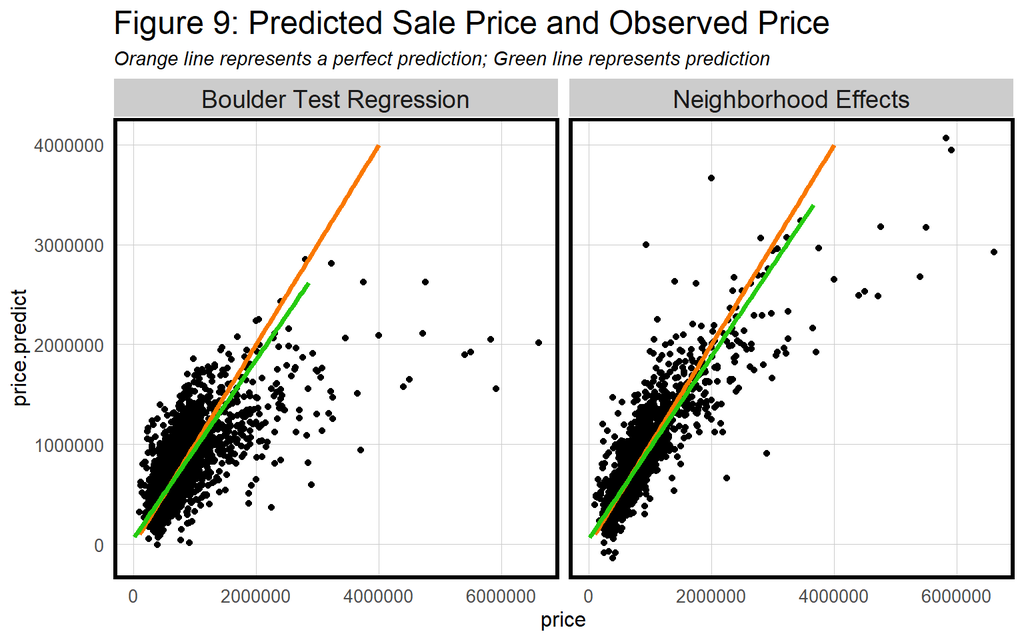

```r
fig_num = 9

ggplot(boulder.test.linear_nhood, aes(price, price.predict)) +
  geom_point() +
  stat_smooth(aes(price, price),
             method = "lm", se = FALSE, size = 1.25, colour="#FA7800") +
  stat_smooth(aes(price.predict, price),
              method = "lm", se = FALSE, size = 1.25, colour="#25CB10") +
  facet_wrap(~regression) +
  xlim(min(boulder.test.linear_nhood$price,0),
       max(boulder.test.linear_nhood$price)) +
  ylim(min(boulder.test.linear_nhood$price.predict,0),
       max(boulder.test.linear_nhood$price.predict)) +
  labs(title=glue("Figure {fig_num}: Predicted Sale Price and Observed Price"),
       subtitle="Orange line represents a perfect prediction; Green line represents prediction") +
  plotTheme() + theme(plot.title = element_text(size = 18, colour = "black"))
## `geom_smooth()` using formula 'y ~ x'
## `geom_smooth()` using formula 'y ~ x'
```

### 4.2.4 Map of Percentage Errors

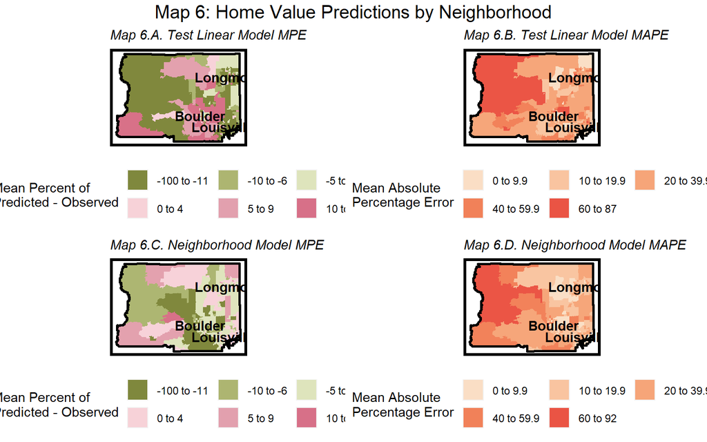

```r
map_num = 6

boulder.test.linear_nhood$regression %>% unique()
## [1] "Boulder Test Regression" "Neighborhood Effects"

boulder.test.nhood.linear =
  merge(
    boulder.nhoods,
    boulder.test.linear_nhood %>%
      filter(regression == 'Boulder Test Regression') %>%
      mutate(count.homes = 1) %>%
      st_drop_geometry() %>%
      group_by(nhood_id) %>%
      summarize(
        count.homes = sum(count.homes, na.rm=TRUE),
        MAE = mean(price.abserror, na.rm=TRUE),
        ME  = mean(price.error, na.rm=TRUE),
        MAPE = mean(price.abserror / price, na.rm=TRUE) * 100,
        MAPE = ifelse(MAPE>100, 100, MAPE),
        MPE = mean(price.error / price, na.rm=TRUE) * 100,
        MPE = ifelse(MPE<=-100, -100, MPE),
        avg.price.predict = mean(price.predict, na.rm=TRUE) %>%
          as.numeric(),
        avg.price  = mean(price, na.rm=TRUE) %>%
          as.numeric(),
        avg.price.lag       = mean(price.lag, na.rm=TRUE) %>%
          as.numeric(),
        avg.price.error.lag = mean(price.error.lag, na.rm=TRUE) %>%
          as.numeric()
      ),
    on='nhood_id',
    all.x = TRUE
  ) %>%
  mutate(
    count.homes = replace_na(count.homes, 0),
    avg.price.lag = replace_na(avg.price.lag, 0),
    avg.price.error.lag = replace_na(avg.price.error.lag, 0),
    avg.price.predict = replace_na(avg.price.predict, 0),
    avg.price = replace_na(avg.price, 0),
    MAPE = replace_na(MAPE, 0),
    ME = replace_na(ME, 0),
    MPE = replace_na(MPE, 0)
    )


boulder.test.nhood.nhood =
  merge(
    boulder.nhoods,
    boulder.test.linear_nhood %>%
      filter(regression == "Neighborhood Effects") %>%
      mutate(count.homes = 1) %>%
      st_drop_geometry() %>%
      group_by(nhood_id) %>%
      summarize(
        count.homes = sum(count.homes, na.rm=TRUE),
        MAE = mean(price.abserror, na.rm=TRUE),
        ME  = mean(price.error, na.rm=TRUE),
        MAPE = mean(price.abserror / price, na.rm=TRUE) * 100,
        MAPE = ifelse(MAPE>100, 100, MAPE),
        MPE = mean(price.error / price, na.rm=TRUE) * 100,
        MPE = ifelse(MPE<=-100, -100, MPE),
        avg.price.predict = mean(price.predict, na.rm=TRUE) %>%
          as.numeric(),
        avg.price  = mean(price, na.rm=TRUE) %>%
          as.numeric(),
        avg.price.lag       = mean(price.lag, na.rm=TRUE) %>%
          as.numeric(),
        avg.price.error.lag = mean(price.error.lag, na.rm=TRUE) %>%
          as.numeric()
      ),
    on='nhood_id',
    all.x = TRUE
  ) %>%
  mutate(
    count.homes = replace_na(count.homes, 0),
    avg.price.lag = replace_na(avg.price.lag, 0),
    avg.price.error.lag = replace_na(avg.price.error.lag, 0),
    avg.price.predict = replace_na(avg.price.predict, 0),
    avg.price = replace_na(avg.price, 0),
    MAPE = replace_na(MAPE, 0),
    ME = replace_na(ME, 0),
    MPE = replace_na(MPE, 0)
    )


Var1_map = var_cut_map(
  focus_sf = boulder.test.nhood.linear,
  var_field = 'MPE',
  focus_pal = "ArmyRose",
  pal_rev = TRUE,
  var_breaks_nomax = c(-100, -10, -5, 0, 5, 10),
  var_title = 'Test Linear Model MPE',
  var_legend = 'Mean Percent of\nPredicted - Observed',
  var_num = 'A'
)

Var2_map = var_cut_map(
  focus_sf = boulder.test.nhood.linear,
  var_field = 'MAPE',
  focus_pal = "Peach",
  pal_rev = TRUE,
  var_breaks_nomax = c(0, 10, 20, 40, 60),
  var_title = 'Test Linear Model MAPE',
  var_legend = 'Mean Absolute\nPercentage Error',
  var_num = 'B'
)

Var3_map = var_cut_map(
  focus_sf = boulder.test.nhood.nhood,
  var_field = 'MPE',
  focus_pal = "ArmyRose",
  pal_rev = TRUE,
  var_breaks_nomax = c(-100, -10, -5, 0, 5, 10),
  var_title = 'Neighborhood Model MPE',
  var_legend = 'Mean Percent of\nPredicted - Observed',
  var_num = 'C'
)

Var4_map = var_cut_map(
  focus_sf = boulder.test.nhood.nhood,
  var_field = 'MAPE',
  focus_pal = "Peach",
  pal_rev = TRUE,
  var_breaks_nomax = c(0, 10, 20, 40, 60),
  var_title = 'Neighborhood Model MAPE',
  var_legend = 'Mean Absolute\nPercentage Error',
  var_num = 'D'
)

title = glue('Map {map_num}: Home Value Predictions by Neighborhood')
grid.arrange(
  Var1_map,
  Var2_map,
  Var3_map,
  Var4_map,
  ncol=2,
  top = textGrob(title,gp=gpar(fontsize=15))
)
```

### 4.2.5 Plot of Percentage Errors

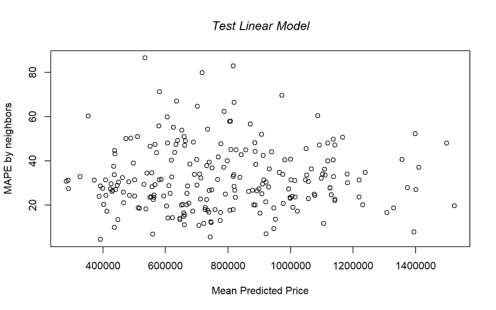

```r
#plot of MAPE by neighbors as a function of mean price by neighbors

fig_num = 10

lin_nhood_plot = plot(
    boulder.test.nhood.linear %>%
      filter(avg.price.predict>0) %>%
      pull(avg.price.predict),
    boulder.test.nhood.linear %>%
      filter(avg.price.predict>0) %>%
      pull(MAPE),
    main=list("Test Linear Model",font = 3),
    xlab="Mean Predicted Price",
    ylab="MAPE by neighbors") +
  plotTheme()
```

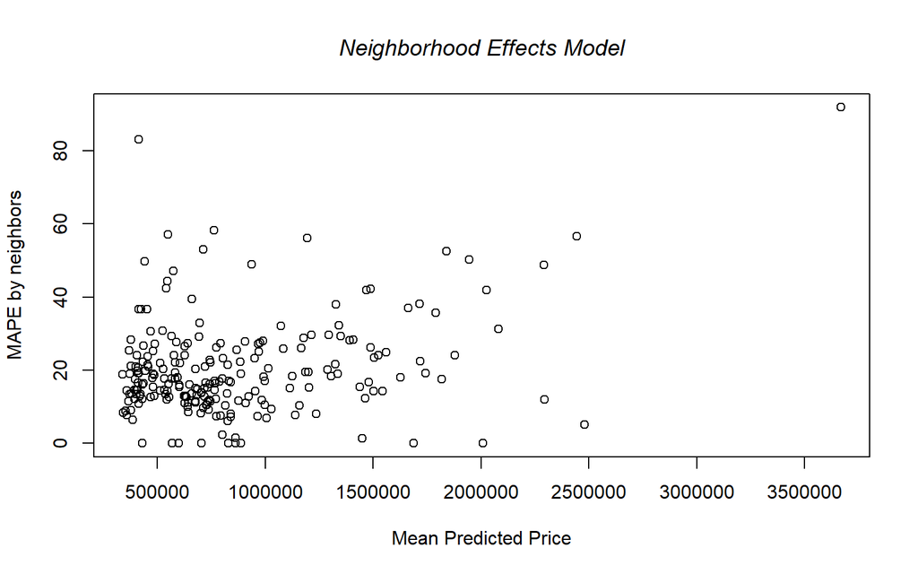

```r
nhood_nhood_plot = plot(
    boulder.test.nhood.nhood %>%
      filter(avg.price.predict>0) %>%
      pull(avg.price.predict),
    boulder.test.nhood.nhood %>%
      filter(avg.price.predict>0) %>%
      pull(MAPE),
    main=list("Neighborhood Effects Model",font = 3),
    xlab="Mean Predicted Price",
    ylab="MAPE by neighbors") +
  plotTheme()
```

[figure not shown]

```r
#plot.new()
par(mfrow=c(1,2), oma=c(0,0,2,0))
Title = glue("Figure {fig_num}: MAPE & Predicted Price by Neighborhood")
mtext(Title, line=0, side=3, outer=TRUE, font=2, cex = 1.5
      )
```

```r
lin_nhood_plot
## NULL
nhood_nhood_plot
## NULL
```

## 4.3 Split City

*Using tidycensus, split your city into two groups (perhaps by race or income)* *and test your model’s generalizability. Is your model generalizable?*

### 4.3.1 Set-Up

```r
boulder.tracts.AMI =
  boulder.tracts.2019 %>%
  mutate(tract.HH.income = ifelse(tract.HH.income>0, tract.HH.income, NA)) %>%
  group_by(above.AMI) %>%
  summarize(
    tract.pop = sum(tract.pop),
    tract.units = sum(tract.units),
    geometry = st_union(geometry),
    AMI = mean(tract.HH.income, na.rm=TRUE),
    tract.area.sqft = st_area(geometry) %>% as.numeric(),
    tract.area.mile = tract.area.sqft / sqmile,
    tract.pop.density = tract.pop/tract.area.sqft
    )

boulder.AMI.test =
  merge(
    boulder.tracts.AMI,
    boulder.test.linear_nhood %>%
      filter(regression == 'Boulder Test Regression') %>%
      mutate(count.homes = 1) %>%
      st_drop_geometry() %>%
      group_by(above.AMI) %>%
      summarize(
        count.homes = sum(count.homes, na.rm=TRUE),
        MAE = mean(price.abserror, na.rm=TRUE),
        ME  = mean(price.error, na.rm=TRUE),
        MAPE = mean(price.abserror / price, na.rm=TRUE) * 100,
        MPE = mean(price.error / price, na.rm=TRUE) * 100,
        avg.price.predict = mean(price.predict, na.rm=TRUE) %>%
          as.numeric(),
        avg.price  = mean(price, na.rm=TRUE) %>%
          as.numeric()
      ),
    on='above.AMI'
  ) %>%
  mutate(
    count.homes = replace_na(count.homes, 0),
    avg.price.predict = replace_na(avg.price.predict, 0),
    avg.price = replace_na(avg.price, 0),
    MAPE = replace_na(MAPE, 0),
    ME = replace_na(ME, 0),
    MPE = replace_na(MPE, 0)
    )


boulder.AMI.nhood =
  merge(
    boulder.tracts.AMI,
    boulder.test.linear_nhood %>%
      filter(regression == "Neighborhood Effects") %>%
      mutate(count.homes = 1) %>%
      st_drop_geometry() %>%
      group_by(above.AMI) %>%
      summarize(
        count.homes = sum(count.homes, na.rm=TRUE),
        MAE = mean(price.abserror, na.rm=TRUE),
        ME  = mean(price.error, na.rm=TRUE),
        MAPE = mean(price.abserror / price, na.rm=TRUE) * 100,
        MPE = mean(price.error / price, na.rm=TRUE) * 100,
        avg.price.predict = mean(price.predict, na.rm=TRUE) %>%
          as.numeric(),
        avg.price  = mean(price, na.rm=TRUE) %>%
          as.numeric()
      ),
    on='above.AMI'
  ) %>%
  mutate(
    count.homes = replace_na(count.homes, 0),
    avg.price.predict = replace_na(avg.price.predict, 0),
    avg.price = replace_na(avg.price, 0),
    MAPE = replace_na(MAPE, 0),
    ME = replace_na(ME, 0),
    MPE = replace_na(MPE, 0)
    )
```

### 4.3.2 Plots

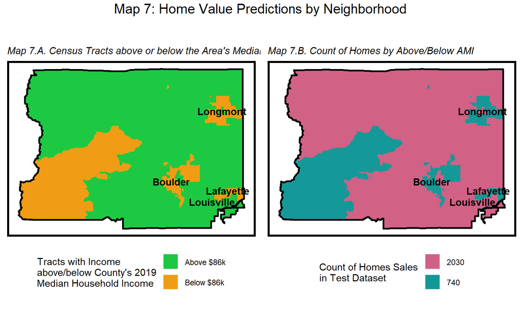

```r
map_num = 7

var_binary_map = function(
  focus_sf = boulder.predict.0.fishnet,
  var_field = 'avg.bedrooms',
  focus_pal = "YlOrRd",
  pal_rev = FALSE,
  var_breaks_nomax = c(0,1,2,3, 5),
  var_title = 'Average Bedrooms',
  var_legend = 'Average Bedrooms',
  var_num = 'A'
  ){
  focus_sf[[var_field]] = focus_sf[[var_field]] %>% as.character()
  focus_length = length(unique(focus_sf[[var_field]]))
  var_pal = hcl.colors(focus_length, #-1,
                       alpha=.95, palette = focus_pal,
                       rev = pal_rev)
  fish_vars_map = function(focus_sf = focus_sf, cut_field = new_var_field,
                           cut_pal=var_pal, cut_breaks = var_breaks,
                           sub_num='A', map_title = ' ', legend_title=NULL
                           ){
    ggplot() +
      geom_sf(data = focus_sf, aes_string(fill = var_field), color = NA) +
      scale_fill_manual(
        values = cut_pal,
        name= legend_title) +
      #geom_cities(data=boulder.cities %>% filter(incorporated=='city'), color='grey10') +
      geom_county() +
      geom_text_sf(sf_to_labels(boulder.cities %>% filter(incorporated=='city'), 'name')) +
      labs(
        #title='',
        subtitle = glue("Map {map_num}.{sub_num}. {map_title}"))+
      theme(legend.position = "bottom",
          legend.spacing.x = unit(.1, 'in')) +
      guides(fill=guide_legend(nrow=2,byrow=TRUE)) +
      mapTheme()}

  return(fish_vars_map(focus_sf = focus_sf, cut_field = new_var_field,
                cut_pal=var_pal, cut_breaks = var_breaks,
                sub_num=var_num, map_title = var_title, legend_title=var_legend))}

Var1_map = var_binary_map(
  focus_sf = boulder.AMI.test %>%
    mutate(above.AMI =ifelse(above.AMI==1,
                             "Above $86k",
                             "Below $86k"
                             )),
  var_field = 'above.AMI',
  focus_pal = "Green-Orange",
  pal_rev = FALSE,
  var_breaks_nomax = c(0),
  var_title = "Census Tracts above or below the Area's Median Income",
  var_legend = "Tracts with Income\nabove/below County's 2019\nMedian Household Income",
  var_num = 'A'
)


Var2_map = var_binary_map(
  focus_sf = boulder.AMI.test,
  var_field = 'count.homes',
  focus_pal = "Temps",
  pal_rev = TRUE,
  var_title = 'Count of Homes by Above/Below AMI',
  var_legend = 'Count of Homes Sales\nin Test Dataset',
  var_num = 'B'
)

Var3_map = var_binary_map(
  focus_sf = boulder.AMI.test %>%
    mutate(MAPE = MAPE %>%
             round(1) %>%
             paste0(., "%")
             ),
  var_field = 'MAPE',
  focus_pal = "Peach",
  pal_rev = TRUE,
  var_title = 'Test Linear Model MAPE',
  var_legend = 'Mean Absolute\nPercentage Error',
  var_num = 'C'
)

Var4_map = var_binary_map(
  focus_sf = boulder.AMI.nhood %>%
    mutate(MAPE = MAPE %>%
             round(1) %>%
             paste0(., "%")
             ),
  var_field = 'MAPE',
  focus_pal = "Peach",
  pal_rev = TRUE,
  var_title = 'Neighborhood Effects Model MAPE',
  var_legend = 'Mean Absolute\nPercentage Error',
  var_num = 'D'
)

title = glue('Map {map_num}: Home Value Predictions by Neighborhood')
grid.arrange(
  Var1_map,
  Var2_map,
  ncol=2,
  top = textGrob(title,gp=gpar(fontsize=15))
)
```